# K-Means Clustering

David Tahi Ulubalang

5/3/2020

# Introduction

## Supervised vs Unsupervised

[figure not shown]

|  | Supervised learning | Unsupervised Learning |
| --- | --- | --- |
| Input data | labelled | Unlabelled |
| Goal | Prediction | Analysis |

## Training Objective

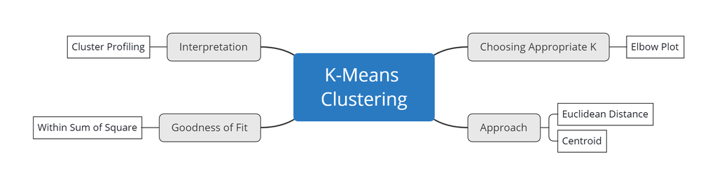

# K-Means Clustering

## How it’s works?

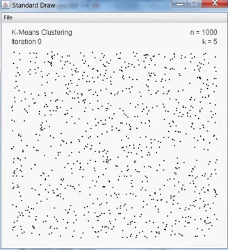

K-Means algoritm :  
1. Choose number of K  
2. The center of cluster (centroid) will be chosen randomly  
3. Compute distances between each point to each centroid  
4. Assign cluster membership  
5. Update the centroid using means  
6. back to step 3  
do the iteration until there is no change in cluster membership

## USA Crime Rate Clustering

### Explore the Data

The data to be used is `USArrest` from `datasets` packages. Take a quick look at the datases, which comprise of arrests per 100.000 residents related to one of three crimes in each of the 50 US states in 1973.

```r
data("USArrests")
head(USArrests)
```

|  | Murder | Assault | UrbanPop | Rape |
| --- | --- | --- | --- | --- |
| Alabama | 13.2 | 236 | 58 | 21.2 |
| Alaska | 10.0 | 263 | 48 | 44.5 |
| Arizona | 8.1 | 294 | 80 | 31.0 |
| Arkansas | 8.8 | 190 | 50 | 19.5 |
| California | 9.0 | 276 | 91 | 40.6 |
| Colorado | 7.9 | 204 | 78 | 38.7 |

- `Murder` : murder arrests per 100,000
- `Assault` : assault arrests per 100,000
- `UrbanPop` : percent of population in urban areas
- `Rape` : rape arrests per 100,000

```r
summary(USArrests)
```

```
##      Murder          Assault         UrbanPop          Rape
##  Min.   : 0.800   Min.   : 45.0   Min.   :32.00   Min.   : 7.30
##  1st Qu.: 4.075   1st Qu.:109.0   1st Qu.:54.50   1st Qu.:15.07
##  Median : 7.250   Median :159.0   Median :66.00   Median :20.10
##  Mean   : 7.788   Mean   :170.8   Mean   :65.54   Mean   :21.23
##  3rd Qu.:11.250   3rd Qu.:249.0   3rd Qu.:77.75   3rd Qu.:26.18
##  Max.   :17.400   Max.   :337.0   Max.   :91.00   Max.   :46.00
```

The summary result showing that every variable has a different range, because the k-means based on euclidian distance, so we need to scaling the value using `scale` function.

```r
crime_scale <- scale(USArrests)
summary(crime_scale)
```

```
##      Murder           Assault           UrbanPop             Rape
##  Min.   :-1.6044   Min.   :-1.5090   Min.   :-2.31714   Min.   :-1.4874
##  1st Qu.:-0.8525   1st Qu.:-0.7411   1st Qu.:-0.76271   1st Qu.:-0.6574
##  Median :-0.1235   Median :-0.1411   Median : 0.03178   Median :-0.1209
##  Mean   : 0.0000   Mean   : 0.0000   Mean   : 0.00000   Mean   : 0.0000
##  3rd Qu.: 0.7949   3rd Qu.: 0.9388   3rd Qu.: 0.84354   3rd Qu.: 0.5277
##  Max.   : 2.2069   Max.   : 1.9948   Max.   : 1.75892   Max.   : 2.6444
```

### Clustering

To find the optimum number of clusters (K) we can use elbow plot method. elbow plot is a technique to choose a point where diminishing returns (wss) are no longer worth the additional cost (number of cluster).

Based on the elbow plot below we will choose K equal to 4 because if we add the K into 5 the total wss not decreasing a lot anymore.

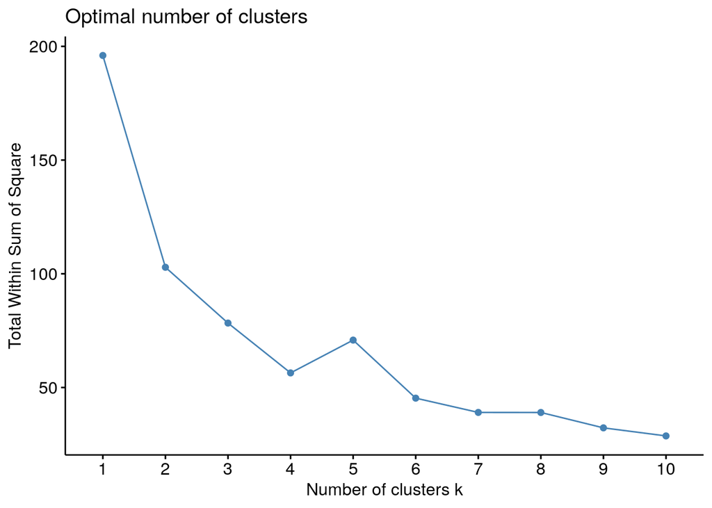

```r
fviz_nbclust(x = crime_scale, FUNcluster = kmeans, "wss")
```

After we know the optimum number of K, now we can create the cluster using `kmeans` function

```r
set.seed(100)
usa_kmeans <- kmeans(x = crime_scale, centers = 4)
```

the clustering result can be visualized using plot below

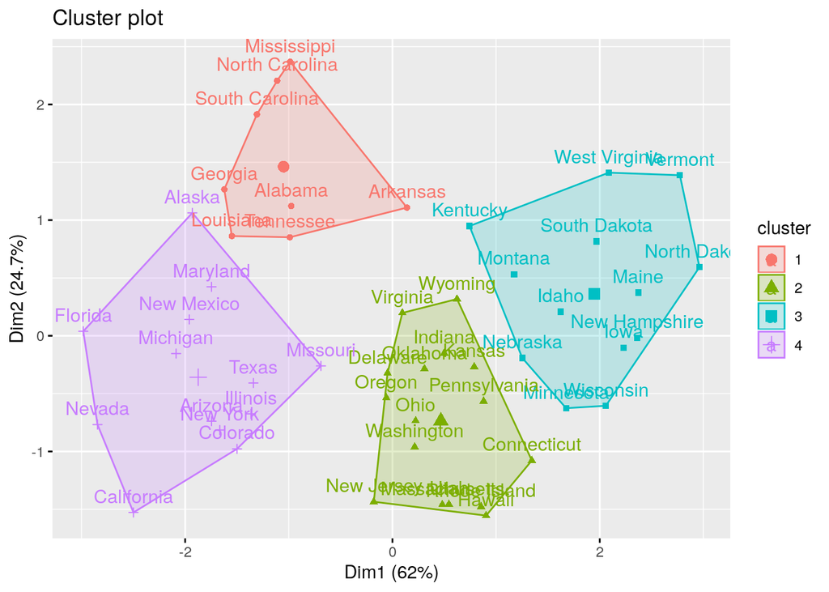

```r
fviz_cluster(data = crime_scale,object =  usa_kmeans)
```

to see the characteristics of each cluster, we can see it from the mean of each variable for each cluster.

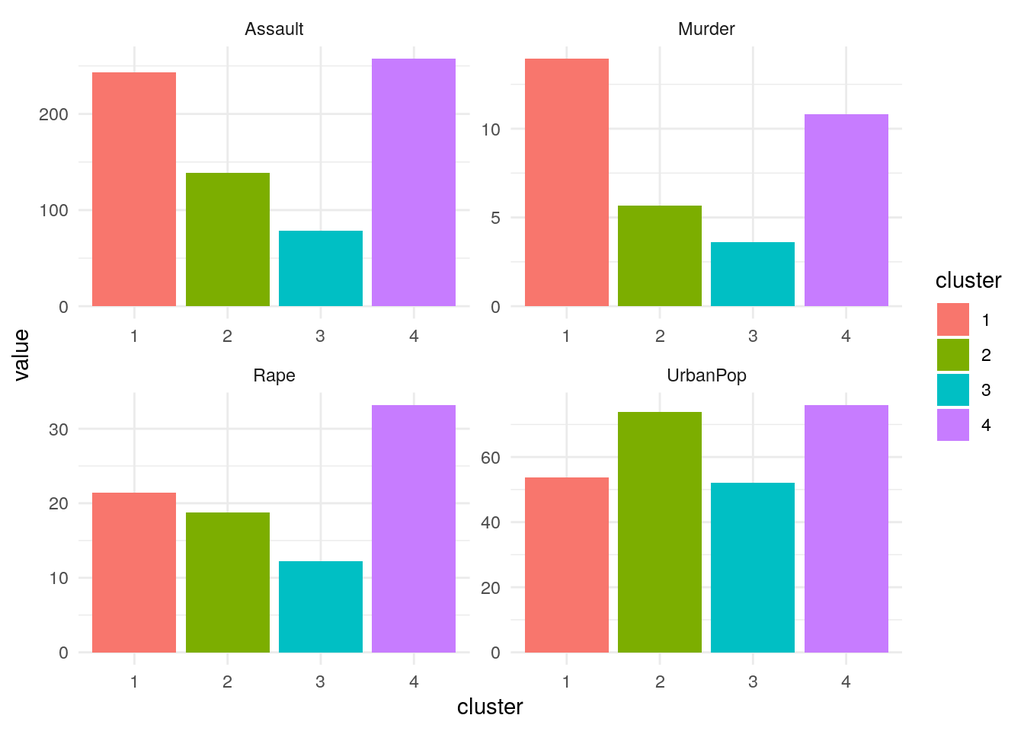

```r
USArrests %>%
  mutate(cluster = as.factor( usa_kmeans$cluster)) %>%
  group_by(cluster) %>%
  summarise_all(mean) %>%
  pivot_longer(cols = -cluster, names_to = "case") %>%
  ggplot(aes(x = cluster, y = value, fill = cluster)) +
  geom_col() +
  # geom_text(aes(label = round(value,1) )) +
  facet_wrap(~case, scales = "free") +
  theme_minimal()
```

# Quiz

1. Which of the following is **Not True** about K-Means?  
   A. Centroid in the first iteration is chosen randomly.  
   B. The greater the value of wss (within sum of square), the better the resulting cluster.  
   C. Clustering proses will stop when there is no change in cluster membership.
2. Please sort the process of making the right cluster  
   A. Create Cluster  
   B. Scaling  
   C. Read Data  
   D. Cluster Profiling  
   E. Elbow Plot